# Attrition Prediction Model

#### 1. Specify the dependent variable 'y' ("Status") and the independent variable 'X' (Predictor variables).

```python
X= df.drop(columns=['status'])
```

```python
y= df['status']
```

```python
X.head(3)
```

|  | distance_from_home | no_of_promotions | risk_of_attrition | potential_rating | bonus | no_courses_taken | time_in_position | manager_sat | employee_sat | Var_rating | percentage_salary_change | age | service_agreement_N | awards_N |
| --- | --- | --- | --- | --- | --- | --- | --- | --- | --- | --- | --- | --- | --- | --- |
| 0 | 0.52 | 2 | 2 | 5 | 0 | 8 | 30 | 81 | 80 | 1 | 3.505101 | 51 | True | True |
| 1 | 0.08 | 3 | 2 | 5 | 2242 | 6 | 5 | 88 | 84 | -1 | 1.502064 | 47 | True | True |
| 2 | 0.51 | 0 | 3 | 3 | 0 | 2 | 53 | 83 | 93 | 0 | 12.670835 | 46 | True | True |

```python
X.shape
```

```
(686, 14)
```

```python
y.head(3)
```

```
0    0
1    0
2    0
Name: status, dtype: int64
```

```python
y.shape
```

```
(686,)
```

> After examining and cleaning the data and feature engineering the initial data set (creating new variables and dropping insignificant variables), we are now left with the final data set (14 columns and 686 rows), which we will now use to train and test the logistic regression model.

#### 2. Split the final data set into two groups: a training set and a test set.

- The training set is used for training the model.
- The test set is used for testing the model.
- We allocate 80% of the data to the training set and 20% to the test set.

```python
# Import the library from Python
from sklearn.model_selection import train_test_split
```

```python
# Specify the training and test sets for both the dependent 'y' and independent 'X' variables
X_train, X_test, y_train, y_test = train_test_split(X, y, train_size=0.8, random_state=42)
```

```python
X_train.shape
```

```
(548, 14)
```

```python
X_test.shape
```

```
(138, 14)
```

```python
y_train.shape
```

```
(548,)
```

```python
y_test.shape
```

```
(138,)
```

> The training set ("X_train" and "y_train") has 548 rows of data or around 80% of the total data set. The test set ("X_test" and "y_test") has 138 rows of data or around 20% of the total data set.

#### 3. Train the Logistic Regression Model:

- Get the Logistic Regression Model from the Python library and
- Train the model by fitting the training data to the Logistic Regression Model

```python
from sklearn.linear_model import LogisticRegression
```

```python
model = LogisticRegression()
```

```python
# Train the model
model.fit(X_train, y_train)
```

```
LogisticRegression()
```

#### 1. Run the Model's predictions

```python
# Run the Logistic Regression Model to predict whether or not employees leave or stay in the company.
y_pred= model.predict(X_test)
```

#### A. Get the Model score on prediction accuracy

```python
model.score(X_test, y_test)
```

```
0.8115942028985508
```

**Insight:** The logistic regression model produced an **accuracy score of 81.2%** which means that its predictions were correct 81.2% of the time. This is an impressive score.

> In general, an accuracy score of 70% or higher is considered to be a great model performance. The model also shows a high sensitivity score of 95.1% which means that it is very good at predicting which employees will stay with the company. However, the model does show a low specificity score of 41.7%, which means that it is not very good at predicting which employees will leave their job.

#### B. Get the Confusion Matrix to Evaluate model performance.

> - The Confusion Matrix is a tabular summary of True/False and Positive/Negative prediction rates.
> - It allows you to compute various performance metrics to evaluate the correctness of a classification model.
> - Each cell on the confusion matrix describes a specific performance metric (**see Figure below**).

```python
# Get the confusion matrix
from sklearn.metrics import confusion_matrix

print(confusion_matrix(y_test,y_pred))
```

```
[[97  5]
 [21 15]]
```

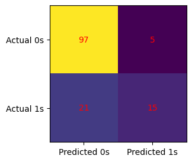

```python
# Get the confusion matrix in a color graph

cm= confusion_matrix(y_test,y_pred)

fig, ax = plt.subplots(figsize=(3,3))
ax.imshow(cm)
ax.grid(False)
ax.xaxis.set(ticks=(0,1), ticklabels=('Predicted 0s', 'Predicted 1s'))
ax.yaxis.set(ticks=(0,1), ticklabels=('Actual 0s', 'Actual 1s'))
ax.set_ylim(1.5, -0.5)
for i in range(2):
    for j in range(2):
        ax.text(j, i, cm[i, j], ha= 'center', va= 'center', color= 'Red')
plt.show()
```

#### Performance metric on the Confusion Matrix:

> - True positive (**TP**) = confusion matrix [0,0] -> upper-left position
> - True negative (**TN**) = confusion matrix [1,1] -> lower-right position
> - False positive (**FP**) = confusion matrix [1,0] -> lower-left position
> - False negative (**FN**) = confusion matrix [0,1] -> upper-right position

#### Performance metric Description:

1. **True Positive (TP)**: a true positive is when the model predicts a "NO", the employee is not leaving (Status = 0) but the actual event is a "NO", the employee actually does not leave. This means the prediction is TRUE. There were 97 instances of a TP event occurring.
2. **True Negative (TN)**: a true negative is when the model predicts a "YES", the employee is leaving (Status = 1), but the actual event is a "YES", the employee actually does leave. This means the prediction is TRUE. There were 15 instances of a TN event occurring.
3. **False Positive (FP)**: a false positive is when the model predicts a "NO", the employee is not leaving (Status = 0), but the actual event is a "YES", the employee does leave. This means the prediction is FALSE. This is also known as a **Type I error.** There were 21 instances of a FP event (Type I error) occurring.
4. **False Negative (FN)**: a false negative is when the model predicts a "YES", the employee is leaving (Status = 1), but the actual event is a "NO", the employee actually stays. This means the prediction is FALSE. This is also known as a **Type II error.** There were 5 instances of a FN event (Type II error) occurring.

### 4. Interpreting the Confusion Matrix - How well did the predictive model perform?

> We get the classification report from the Python library in order to interpret the confusion matrix and understand how well the predictive model performed.

```python
from sklearn.metrics import classification_report
```

```python
print(classification_report(y_test, y_pred))
```

```
              precision    recall  f1-score   support

           0       0.82      0.95      0.88       102
           1       0.75      0.42      0.54        36

    accuracy                           0.81       138
   macro avg       0.79      0.68      0.71       138
weighted avg       0.80      0.81      0.79       138
```

#### 1. Model Accuracy:

Model accuracy is how often your classification model is correct. This means, out of all the predicted values, how many values are actually correct? Model accuracy is calculated by dividing all the true values (TP+TN) by the total number of results:

> Accuracy = (TP + TN) / (TP + FP + TN + FN) = 112/138 = **81.16%**

Our model made a correct prediction 81% of the time. However, accuracy only captures the share of correctly predicted results in the total number of results. It does not account for any misclassifications or false results. With accuracy at 81%, we still don't know how the remaining 20% is distributed between false positive and false negative.

#### 2. Model Sensitivity

This metric helps you understand how often the model predicts a correct "NO", the employee is not leaving (Status = 0). It is calculated by dividing the TP rate by the number of TP and the number of actual positive results (FN).

> Sensitivity = TP / (TP + FN) = 97/102 = **95.1%**

The attrition predictive model's sensitivity is high at 95.1%. This means there are few false negative results where the model predicts a "YES", the employee is leaving (Status = 1), but the actual event is a "NO", the employee actually stays.

Sensitivity and recall are interchangeable terms, and both are often used in statistics (see the classification report above).

#### 3. Model Specificity

Model specificity is the true negative rate and is the opposite of sensitivity. Specificity is calculated by dividing the number of TNs by the total number of actual negative results: TN + FP.

> Specificity = TN / (TN + FP) = 15/36 = **41.7%**

Specificity helps you to understand how often the classification model predicts a "YES" (employee is leaving) when the actual event is a "YES" (employee does leave). The model shows a low specificity score of 41.7%, which means **it is not very good at predicting when the employee is leaving.** This is due to the high number of false positives (a total of 21 FP instances, or roughly 15% of the total test sample data set).

The model's propensity for a Type I error (i.e., misclassifying an attriting employee), is due to the low number of attrition instances (only around 25% of the total data set) with which the model is trained on. In machine learning, this is known as a **"class imbalance"** problem, where the machine is trained on a dataset where there is insufficient data of a particular class.

#### 4. Model Precision

Precision helps you to understand how often a model correctly predicts a positive result. Ideally, a precision of 100% indicates that whenever the model predicts positive, it is 100% correct. Precision is calculated by the number of TP divided by the number of positive results (TP + FP):

> Precision = TP / (TP + FP) = 97/118 = **82.2%**

Getting a precision rate of 100% means that there is no instance of a false positive. This means that none of the negative values get predicted as a positive instance. In reality, this may not be possible, since the training or test data will always likely have a class imbalance problem. **In general, it is accepted that any accuracy greater than 70% could be considered a great model performance.**

#### X. Concluding Remarks

We believe that we have achieved the two goals stated at the outset of this report.

- **Goal #1**: we have surfaced and presented 16 business insights that identify the significant factors that cause employee attrition. We also gave recommendations on what programs the company can design to reduce the high attrition rate.
- **Goal #2**: we built a model that correctly predicts attrition 81.2% of the time. This is an impressive accuracy score. However, there is room for improving the model's specificity score of 41.7%. Overall, we believe our model is an effective tool in predicting attrition and in helping the company design programs that will improve its attrition rate.